# acumen benchmark report

Generated 2026-10-27 17:06 UTC · 162 runs · figures show the valid split · arms: noskill, v1, v2, v3 · tasks: box, composition, dotplot, heatmap, volcano, volcano_r

⚠ skill arm 'v1' loaded the skill in only 1/36 runs

⚠ skill arm 'v2' loaded the skill in only 26/54 runs

## Overview

Per-run means over the valid split; error bars are standard errors.

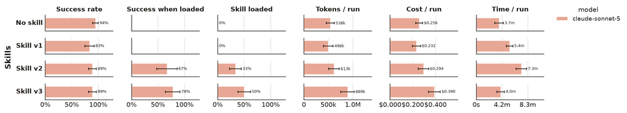

### Success across versions

Each line follows one model's success rate as the skill goes from no skill through each version. Solid lines are the valid tasks and dashed lines are the train tasks. The grey line is the mean across models and sits on top. The newest version has only valid runs, so the train lines stop one step short.

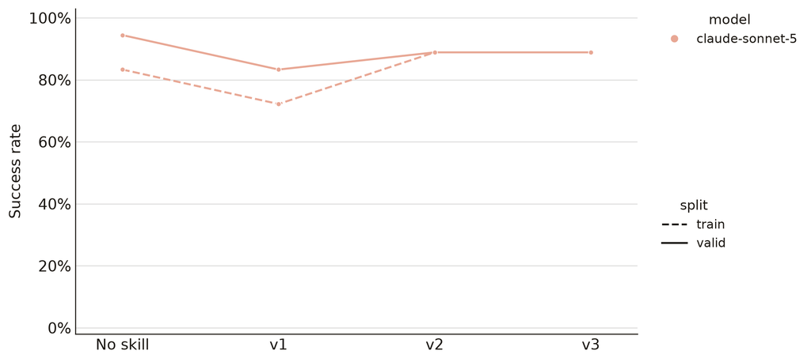

### Cost vs. success

One mark per model and skill version, where colour is the model and the ✕ is that model's no-skill baseline. Arrows join one model's own marks in version order, baseline to v1 to v2 and on, so a chain is that model's path and never crosses to another. The grey mark pools every model for that version, with standard errors on both axes, and its chain is the pooled path. The staircase is the Pareto frontier: anything below and to the right of it is dominated, because something on the line costs less *and* succeeds more.

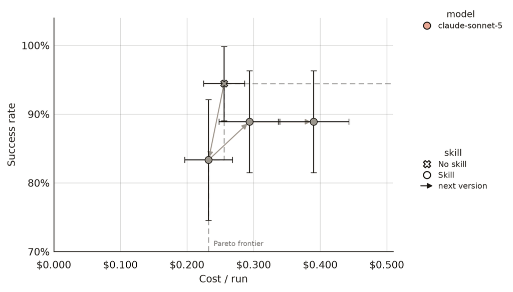

### Is the difference real?

Each version is compared with the baseline on two separate questions: does it succeed more often, and does it cost less per run? Each is a one-sided test, and each is corrected on its own, with a Benjamini–Hochberg false-discovery rate (*FDR q*) across the versions. Success is one family and cost is another, so a version can show a real gain on success, on cost, or on both, and the table says which. A gain the resampling cannot tell apart from noise leaves q high, which says the evidence is thin rather than that the version is bad. Best value in each column is **bold**, highest for the rates and lowest for cost and for the p- and q-values. *On frontier* is how often an arm holds the Pareto frontier across resamples. Resampling is over the 6 tasks, paired across arms, so the unit is the task rather than the run.

| Skill | Success rate | Cost / run | On frontier | Success vs No skill Δ rate | Success vs No skill p | Success vs No skill FDR q | Cost vs No skill Δ cost | Cost vs No skill p | Cost vs No skill FDR q |
| --- | --- | --- | --- | --- | --- | --- | --- | --- | --- |
| No skill | **94.4%** | $0.256 | 78.1% | — | — | — | — | — | — |
| Skill v1 | 83.3% | **$0.232** | **82.4%** | -11.1pp | **1.000** | **1.000** | **-$0.023** | **0.164** | **0.493** |
| Skill v2 | 88.9% | $0.294 | 19.7% | **-5.6pp** | **1.000** | **1.000** | +$0.038 | 0.794 | 0.997 |
| Skill v3 | 88.9% | $0.390 | 0.0% | **-5.6pp** | **1.000** | **1.000** | +$0.134 | 0.997 | 0.997 |

### Did it help when it actually loaded?

If a skill never loads, the agent never reads it, so that run tells us nothing about the skill itself and only measures the baseline. Setting those runs aside lets us see whether the guidance helped in the runs where it did reach the agent. This helps tell apart a skill that fails to load from one that loads but still doesn't help. In the plot below, every dot is one model on one skill version. The colour shows the change in success rate against the baseline, green for better and red for worse. The size shows how often the skill loaded, and a hollow ring means it never did. Each loaded run is compared with the baseline on the very same task and model, and those differences are averaged, so the number is a real effect and does not depend on which tasks happened to load. It is still measured only on the tasks that loaded, and it does not test whether a gain is more than noise. For that, look at the significance test above.

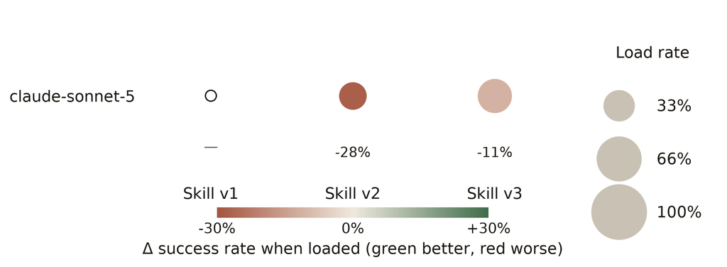

## Held-out test

This is the truly held-out split. It is benched once at the very end of a fit, on the best kept version and the baseline, and nothing in the loop ever sees it. Training learns from the train split and the best version is picked on valid, so the test split is the first and only place the skill meets these tasks. Read it as the honest final estimate of what the skill buys.

Skill version used for the held-out test: **v2**, the best on validation and the version to ship (`acumen ship --skill v2`).

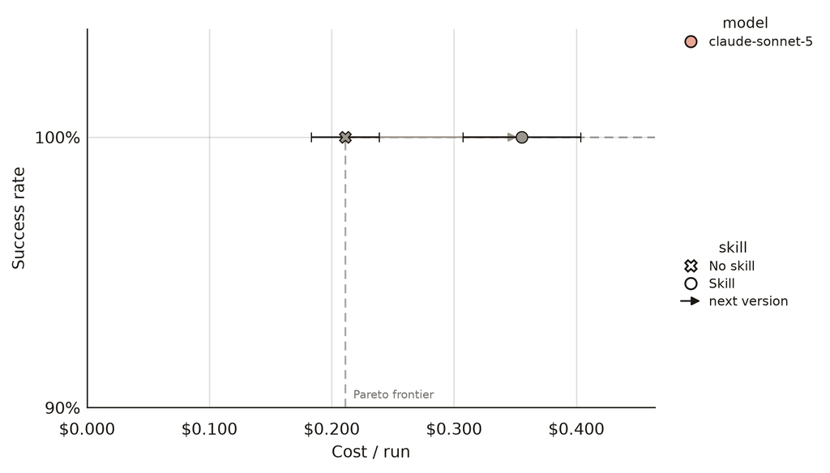

| Skill | Success rate | Cost / run | On frontier | Success vs No skill Δ rate | Success vs No skill p | Success vs No skill FDR q | Cost vs No skill Δ cost | Cost vs No skill p | Cost vs No skill FDR q |
| --- | --- | --- | --- | --- | --- | --- | --- | --- | --- |
| No skill | **100.0%** | **$0.211** | **99.7%** | — | — | — | — | — | — |
| Skill v2 | **100.0%** | $0.355 | 0.3% | +0.0pp | 1.000 | 1.000 | +$0.144 | 0.997 | 0.997 |

## Per-task breakdown

### box

**train:** `kang2018.h5ad` in the working directory holds Kang et al. 2018 PBMCs: raw UMI counts in `X`; `obs` columns `label` (`ctrl` or `stim`, interferon-beta), `replicate` (patient id) and `cell_type`. In CD4 T cells, normalise each cell to 10,000 total counts and apply natural log1p. For each `replicate` x `label` sample, take the mean CCR7 value over its cells. Draw a box plot of these per-sample means by `label`, with each sample as a jittered point on top. Save the figure as files in the working directory. Report the label (ctrl or stim) whose per-sample means have the higher median.

**valid:** `kang2018.h5ad` in the working directory holds Kang et al. 2018 PBMCs: raw UMI counts in `X`; `obs` columns `label` (`ctrl` or `stim`, interferon-beta), `replicate` (patient id) and `cell_type`. In B cells, normalise each cell to 10,000 total counts and apply natural log1p. For each `replicate` x `label` sample, take the mean HLA-DRA value over its cells. Draw a box plot of these per-sample means by `label`, with each sample as a jittered point on top. Save the figure as files in the working directory. Report the label (ctrl or stim) whose per-sample means have the higher median.

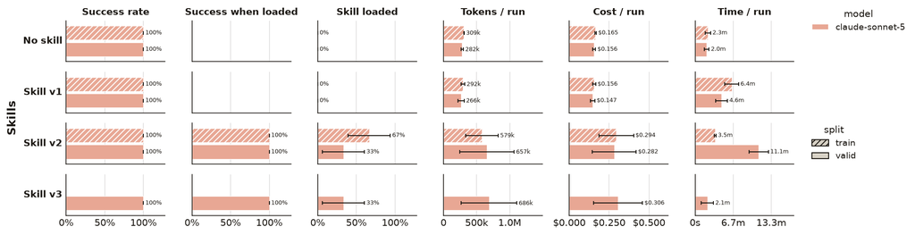

### composition

**train:** `kang2018.h5ad` in the working directory holds Kang et al. 2018 PBMCs: raw UMI counts in `X`; `obs` columns `label` (`ctrl` or `stim`, interferon-beta), `replicate` (patient id) and `cell_type`. Draw a stacked bar chart of cell-type composition: one bar per `replicate` x `label` sample, each segment the share of that sample's cells in one `cell_type`. Save the figure as files in the working directory. Report the cell type with the largest share in the sample patient_107 under ctrl, written exactly as its `cell_type` label.

**valid:** `kang2018.h5ad` in the working directory holds Kang et al. 2018 PBMCs: raw UMI counts in `X`; `obs` columns `label` (`ctrl` or `stim`, interferon-beta), `replicate` (patient id) and `cell_type`. Draw a stacked bar chart of cell-type composition: one bar per `replicate` x `label` sample, each segment the share of that sample's cells in one `cell_type`. Save the figure as files in the working directory. Report the cell type with the largest share in the sample patient_1016 under stim, written exactly as its `cell_type` label.

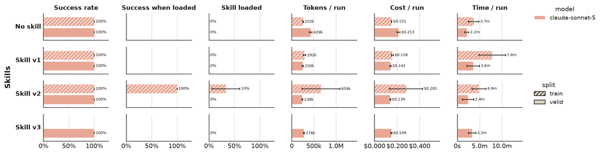

### dotplot

**train:** `kang2018.h5ad` in the working directory holds Kang et al. 2018 PBMCs: raw UMI counts in `X`; `obs` columns `label` (`ctrl` or `stim`, interferon-beta), `replicate` (patient id) and `cell_type`. Draw a marker dot plot of the genes MS4A1, CD79A, CD79B, CD19, TCL1A across all cell types: dot size is the fraction of cells with a raw count above 0, colour the mean expression. Save the figure as files in the working directory. Report the gene from that list expressed (raw count above 0) in the largest fraction of B cells, both labels pooled.

**valid:** `kang2018.h5ad` in the working directory holds Kang et al. 2018 PBMCs: raw UMI counts in `X`; `obs` columns `label` (`ctrl` or `stim`, interferon-beta), `replicate` (patient id) and `cell_type`. Draw a marker dot plot of the genes PRF1, KLRD1, FCGR3A, CCL5 across all cell types: dot size is the fraction of cells with a raw count above 0, colour the mean expression. Save the figure as files in the working directory. Report the gene from that list expressed (raw count above 0) in the largest fraction of NK cells, both labels pooled.

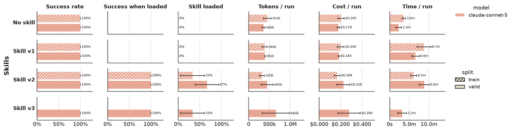

### heatmap

**train:** `kang2018.h5ad` in the working directory holds Kang et al. 2018 PBMCs: raw UMI counts in `X`; `obs` columns `label` (`ctrl` or `stim`, interferon-beta), `replicate` (patient id) and `cell_type`. Keep the six cell types B cells, CD14+ Monocytes, CD4 T cells, CD8 T cells, FCGR3A+ Monocytes and NK cells. For each cell type x `label`, sum raw counts over all its cells (patients pooled) and convert to counts per million (CPM). Per gene and cell type, log2FC = log2(CPM_stim + 1) - log2(CPM_ctrl + 1). Among genes with at least 100 counts in CD14+ Monocytes (stim plus ctrl), take the 30 with the largest |log2FC| in CD14+ Monocytes. Centre each gene by subtracting its mean log2FC across the six cell types. Draw a heatmap of the centred values, genes by cell type, on a diverging colour scale capped at -2 and +2. Save the figure as files in the working directory. Report how many heatmap cells are saturated, that is have |centred value| > 2.

**valid:** `kang2018.h5ad` in the working directory holds Kang et al. 2018 PBMCs: raw UMI counts in `X`; `obs` columns `label` (`ctrl` or `stim`, interferon-beta), `replicate` (patient id) and `cell_type`. Keep the six cell types B cells, CD14+ Monocytes, CD4 T cells, CD8 T cells, FCGR3A+ Monocytes and NK cells. For each cell type x `label`, sum raw counts over all its cells (patients pooled) and convert to counts per million (CPM). Per gene and cell type, log2FC = log2(CPM_stim + 1) - log2(CPM_ctrl + 1). Among genes with at least 100 counts in NK cells (stim plus ctrl), take the 40 with the largest |log2FC| in NK cells. Centre each gene by subtracting its mean log2FC across the six cell types. Draw a heatmap of the centred values, genes by cell type, on a diverging colour scale capped at -1.5 and +1.5. Save the figure as files in the working directory. Report how many heatmap cells are saturated, that is have |centred value| > 1.5.

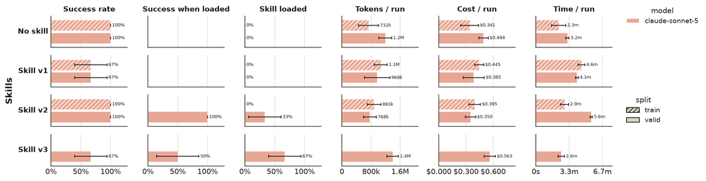

### volcano

**train:** `kang2018.h5ad` in the working directory holds Kang et al. 2018 PBMCs: raw UMI counts in `X`; `obs` columns `label` (`ctrl` or `stim`, interferon-beta), `replicate` (patient id) and `cell_type`. Make a volcano plot of pseudobulk differential expression, stim vs ctrl, in B cells. Build one pseudobulk sample per `replicate` x `label` by summing raw counts over its cells; drop genes with fewer than 10 counts summed over all pseudobulk samples. Test with PyDESeq2, design `~ replicate + label`, contrast stim vs ctrl, no fold-change shrinkage, independent-filtering alpha 0.1; drop genes with a missing padj. A gene is significant when padj < 0.1 and |log2 fold change| > 0.5; highlight the significant genes. Save the figure as files in the working directory. Report the number of significant genes.

**valid:** `kang2018.h5ad` in the working directory holds Kang et al. 2018 PBMCs: raw UMI counts in `X`; `obs` columns `label` (`ctrl` or `stim`, interferon-beta), `replicate` (patient id) and `cell_type`. Make a volcano plot of pseudobulk differential expression, stim vs ctrl, in NK cells. Build one pseudobulk sample per `replicate` x `label` by summing raw counts over its cells; drop genes with fewer than 10 counts summed over all pseudobulk samples. Test with PyDESeq2, design `~ replicate + label`, contrast stim vs ctrl, no fold-change shrinkage, independent-filtering alpha 0.05; drop genes with a missing padj. A gene is significant when padj < 0.05 and |log2 fold change| > 1; highlight the significant genes. Save the figure as files in the working directory. Report the number of significant genes.

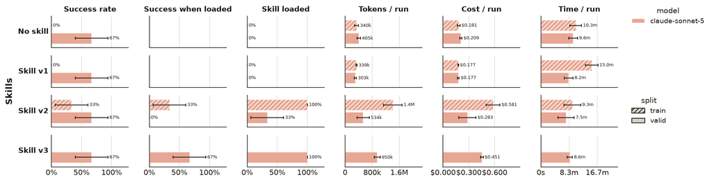

### volcano_r

**train:** `kang2018.h5ad` in the working directory holds Kang et al. 2018 PBMCs: raw UMI counts in `X`; `obs` columns `label` (`ctrl` or `stim`, interferon-beta), `replicate` (patient id) and `cell_type`. Make a volcano plot of pseudobulk differential expression, stim vs ctrl, in CD4 T cells. Build one pseudobulk sample per `replicate` x `label` by summing raw counts over its cells; drop genes with fewer than 10 counts summed over all pseudobulk samples. Do the test and the plot in R with DESeq2 and ggplot2, run through `Rscript`; you may build the pseudobulk count table in Python first. Use design `~ replicate + label`, contrast stim vs ctrl, no fold-change shrinkage, independent-filtering alpha 0.1; drop genes with a missing padj. A gene is significant when padj < 0.1 and |log2 fold change| > 0.5; highlight the significant genes. Save the figure as files in the working directory. Report the number of significant genes.

**valid:** `kang2018.h5ad` in the working directory holds Kang et al. 2018 PBMCs: raw UMI counts in `X`; `obs` columns `label` (`ctrl` or `stim`, interferon-beta), `replicate` (patient id) and `cell_type`. Make a volcano plot of pseudobulk differential expression, stim vs ctrl, in FCGR3A+ Monocytes. Build one pseudobulk sample per `replicate` x `label` by summing raw counts over its cells; drop genes with fewer than 10 counts summed over all pseudobulk samples. Do the test and the plot in R with DESeq2 and ggplot2, run through `Rscript`; you may build the pseudobulk count table in Python first. Use design `~ replicate + label`, contrast stim vs ctrl, no fold-change shrinkage, independent-filtering alpha 0.05; drop genes with a missing padj. A gene is significant when padj < 0.05 and |log2 fold change| > 1; highlight the significant genes. Save the figure as files in the working directory. Report the number of significant genes.

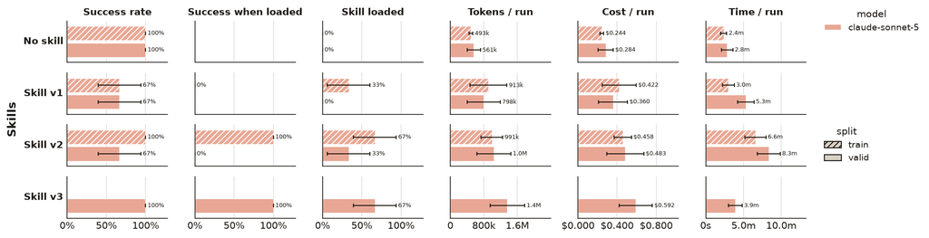

## Skill versions

Why each version was written, and what changed from its parent.

### Skill v1

initial draft

(no rationale recorded)

Initial version — no parent to diff against.

### Skill v2

parent: v1 · sha256:29e95380c590…

The wiki showed one dominant failure mode: the skill almost never loaded (0 of 3 in box,  
composition, dotplot, and heatmap; 1 of 3 in volcano_r; 0 of 3 in volcano), with every hypothesis  
tagged description-fixable. Reading the actual task prompts explained why: each task opens with  
"You are completing one task in an automated benchmark. Your work is graded by a script, not read  
by a human," yet v1's description sold the skill as an "Always-on persona ... write analysis code  
a colleague can read" -- a pitch about human readability that is directly contradicted by the  
task's own framing, so the agent reasonably judged it irrelevant. The description also read like a  
toggleable command ("Always-on persona", with an on, off, status style argument-hint), which the  
heatmap hypothesis flagged separately as looking like a manual switch rather than content to  
auto-invoke. I rewrote the description to drop the persona and toggle framing and instead name the  
category of goal actually present in every task -- writing or reviewing R or Python code that  
computes a result or figure from experimental or omics data -- and to foreground what the body  
actually prevents (silent bugs that change the final number: ad hoc recodes, positional joins,  
unseeded randomness, AnnData view-vs-copy mistakes, double-filtering), which matches the  
benchmark's real grading criterion, a correct answer.md, rather than human readability. I also  
deleted a "Draft status, not assessed" line in the body, which could only ever undercut the  
skill's authority on the rare run where it did load. Finally, for volcano (noskill tagged  
body-fixable: runs disagree on the exact significant-gene count because each invents its own  
low-count pre-filter before the DESeq2 fit, which changes the multiple-testing universe and shifts  
the count), I added one generic rule to the existing checks "do not write" list against layering an  
invented filter or cutoff in front of a method that already filters or corrects internally --  
applicable to any statistical method, not tied to this dataset or package, so it should generalise  
rather than overfit. I left the heatmap and volcano_r regressions alone beyond the description fix:  
drilling into the one run where volcano_r's skill did load showed the agent correctly deprioritized  
the skill's project-layout conventions, per the existing order-of-authority rule, and the run's  
failure was a sandbox write-hook falsely rejecting the script path -- unrelated to skill content and  
explicitly tagged not-skill-fixable, so no body change addresses it.

SKILL.md

|  | v1 |  | v2 |
| --- | --- | --- | --- |
| 1 | --- | 1 | --- |
| 2 | name: lucid-coder | 2 | name: lucid-coder |
| 3 | description: >- | 3 | description: >- |
| 4 | Always-on persona for scientific R and Python: write analysis code a | 4 | Use when writing, debugging or reviewing data-analysis code in R or |
| 5 | colleague can read, rerun and trust on the first pass. Use when writing, | 5 | Python for bioinformatics, computational biology, genomics or |
| 6 | fixing, refactoring or reviewing bioinformatics, statistics or | 6 | statistics: any script, notebook or figure that computes a result or |
| 7 | computational-biology scripts, notebooks, Rmd/Quarto, figures or | 7 | plot from experimental or omics data. Prevents the silent bugs (ad hoc |
| 8 | Snakemake rules. Applies the house style, the check policy and the | 8 | recodes and cutoffs, positional joins, unseeded randomness, AnnData |
| 9 | user's approved learned rules. | 9 | view/copy mistakes, double-filtering a method that already filters) |
|  |  | 10 | that most often change the final number, and gives reproducible script |
|  |  | 11 | structure, checks, naming and figure conventions. |
| 10 | argument-hint: "[on\|off\|status\|nudge on\|nudge off\|lang r\|python\|both\|auto]" | 12 | argument-hint: "[on\|off\|status\|nudge on\|nudge off\|lang r\|python\|both\|auto]" |
| 11 | --- | 13 | --- |
| 12 |  | 14 |  |
| … |  |  |  |
| 16 | That reader is a colleague, a reviewer, or the author in six months. | 18 | That reader is a colleague, a reviewer, or the author in six months. |
| 17 | Optimise for one-pass understanding and a clean rerun. Do not optimise for | 19 | Optimise for one-pass understanding and a clean rerun. Do not optimise for |
| 18 | token count or line count. Brevity breaks ties; it is never the goal. | 20 | token count or line count. Brevity breaks ties; it is never the goal. |
| 19 |  |  |  |
| 20 | Draft status: this persona is a plan artefact. Its effect on agent output is |  |  |
| 21 | **not assessed** until the evaluation in `PLAN.md` section 8 runs. |  |  |
| 22 |  | 21 |  |
| 23 | ## Order of authority | 22 | ## Order of authority |
| 24 |  | 23 |  |
| … |  |  |  |
| 225 | - printed `table(a == b)` presented as a check | 224 | - printed `table(a == b)` presented as a check |
| 226 | - checks that cannot fail | 225 | - checks that cannot fail |
| 227 | - new `check_*.R` files | 226 | - new `check_*.R` files |
|  |  | 227 | - an invented pre-filter or cutoff layered in front of a method that |
|  |  | 228 | already filters or corrects internally (its own low-count filter, |
|  |  | 229 | its own multiple-testing correction): the two compound and silently |
|  |  | 230 | shift the result. Apply the method once, with the threshold the user |
|  |  | 231 | stated; let it make its own filtering decision when they did not. |
| 228 |  | 232 |  |
| 229 | Prefer completeness by construction, for example a completed sample x type | 233 | Prefer completeness by construction, for example a completed sample x type |
| 230 | grid, over an assert after the fact. | 234 | grid, over an assert after the fact. |
| … |  |  |  |

### Skill v3

parent: v2 · sha256:41dd300d7b9c…

The one task with a real, outcome-changing, body-fixable gap is `volcano`: across noskill/v1/v2 the pseudobulk+PyDESeq2 pipeline is fully specified by the task prompt (exact threshold, design, contrast, alpha), yet agents still land on slightly different significant-gene counts (835/838/839) because each hand-rolls the pseudobulk aggregation and the covariate dtypes differently, with no check to catch a silent row-count/total mismatch or an accidentally-numeric grouping covariate. I added two generalizable fixes to the body (not tied to this dataset): (1) a new default check that a grouped aggregation (pseudobulk, groupby-sum) must produce exactly one row per group and conserve each column's total, since two equivalent-looking implementations (groupby vs. one-hot-matmul) can silently drop/duplicate rows; (2) sharpened the existing "set factor levels explicitly" rule to call out that a blocking/grouping covariate (batch, replicate, donor) in a model formula must be cast to character/factor, since a numeric ID silently fits as a continuous slope instead of one coefficient per level with no error. Both match the skill's existing "silent data loss" check philosophy and should reduce run-to-run variance on any aggregate-then-model pipeline, not just this one.

SKILL.md

|  | v2 |  | v3 |
| --- | --- | --- | --- |
| … |  |  |  |
| 188 | adata_ad = adata[adata.obs["disease"] == "AD"].copy() | 188 | adata_ad = adata[adata.obs["disease"] == "AD"].copy() |
| 189 | ``` | 189 | ``` |
| 190 |  | 190 |  |
|  |  | 191 | - A grouped aggregation that collapses rows into one per group (pseudobulk, |
|  |  | 192 | `groupby().sum()`, a crosstab) must produce exactly one row per group and |
|  |  | 193 | conserve each column's total between the pre- and post-aggregation frames. |
|  |  | 194 | Two equivalent-looking implementations (a `groupby` vs. a one-hot-matmul) |
|  |  | 195 | can still drop or duplicate rows differently when a key is missing or |
|  |  | 196 | mistyped; check the total and row count, don't just trust the call. |
|  |  | 197 |  |
| 191 | ## Checks: few, consequential, able to fail | 198 | ## Checks: few, consequential, able to fail |
| 192 |  | 199 |  |
| 193 | A check earns its place only if it stops silent data loss, a silent | 200 | A check earns its place only if it stops silent data loss, a silent |
| … |  |  |  |
| 199 | `relationship = "many-to-one"` over an extra assert. | 206 | `relationship = "many-to-one"` over an extra assert. |
| 200 | 4. IDs match before any positional copy, for example `identical(a$barcode, b$barcode)`. | 207 | 4. IDs match before any positional copy, for example `identical(a$barcode, b$barcode)`. |
| 201 | 5. Expected outputs exist and are non-empty. | 208 | 5. Expected outputs exist and are non-empty. |
|  |  | 209 | 6. A grouped aggregation keeps exactly one row per group and conserves each |
|  |  | 210 | column's total (the aggregated sum equals the pre-aggregation sum). |
| 202 |  | 211 |  |
| 203 | Add a check beyond these only for a known scientific assumption that would | 212 | Add a check beyond these only for a known scientific assumption that would |
| 204 | otherwise fail silently. Examples: a filter that feeds a model or figure left | 213 | otherwise fail silently. Examples: a filter that feeds a model or figure left |
| … |  |  |  |
| 270 | Pass `random_state` as an argument in Python; set `scvi.settings.seed`. | 279 | Pass `random_state` as an argument in Python; set `scvi.settings.seed`. |
| 271 | Pass `seed =` to `geom_text_repel()` and `position_jitter()`. | 280 | Pass `seed =` to `geom_text_repel()` and `position_jitter()`. |
| 272 | - Never pick clusters by number from an unseeded run. | 281 | - Never pick clusters by number from an unseeded run. |
| 273 | - Set factor levels explicitly before modelling or plotting. | 282 | - Set factor levels explicitly before modelling or plotting. A grouping or |
|  |  | 283 | blocking covariate in a model formula (batch, replicate, donor) must be |
|  |  | 284 | character or factor, never left numeric — a numeric covariate silently |
|  |  | 285 | fits as a continuous slope instead of one coefficient per level, and |
|  |  | 286 | nothing errors to flag it. |
| 274 | - Name the multiple-testing family. | 287 | - Name the multiple-testing family. |
| 275 | - End R scripts with `writeLines(capture.output(sessionInfo()), file.path(run_dir, "session_info.txt"))`. | 288 | - End R scripts with `writeLines(capture.output(sessionInfo()), file.path(run_dir, "session_info.txt"))`. |
| 276 | In Python, `sc.logging.print_versions()` or `session_info.show()`, written | 289 | In Python, `sc.logging.print_versions()` or `session_info.show()`, written |
| … |  |  |  |

## Runs

Full data: report.csv

| arm | split | task | model | rep | skill loaded | reason | turns | total tok | cost / run $ | time | transcript |
| --- | --- | --- | --- | --- | --- | --- | --- | --- | --- | --- | --- |
| noskill | test | box | claude-sonnet-5 | 1 | — | ok | 14 | 561,682 | 0.232 | 3.7m | view |
| noskill | test | box | claude-sonnet-5 | 2 | — | ok | 6 | 223,992 | 0.138 | 1.4m | view |
| noskill | test | box | claude-sonnet-5 | 3 | — | ok | 5 | 185,147 | 0.126 | 1.1m | view |
| noskill | test | composition | claude-sonnet-5 | 1 | — | ok | 6 | 223,965 | 0.134 | 38s | view |
| noskill | test | composition | claude-sonnet-5 | 2 | — | ok | 8 | 302,274 | 0.156 | 6.2m | view |
| noskill | test | composition | claude-sonnet-5 | 3 | — | ok | 5 | 184,085 | 0.124 | 58s | view |
| noskill | test | dotplot | claude-sonnet-5 | 1 | — | ok | 7 | 260,771 | 0.141 | 1.3m | view |
| noskill | test | dotplot | claude-sonnet-5 | 2 | — | ok | 8 | 300,178 | 0.152 | 1.7m | view |
| noskill | test | dotplot | claude-sonnet-5 | 3 | — | ok | 6 | 223,397 | 0.133 | 1.1m | view |
| noskill | test | heatmap | claude-sonnet-5 | 1 | — | ok | 26 | 1,168,507 | 0.454 | 2.3m | view |
| noskill | test | heatmap | claude-sonnet-5 | 2 | — | ok | 30 | 1,430,172 | 0.563 | 3.6m | view |
| noskill | test | heatmap | claude-sonnet-5 | 3 | — | ok | 15 | 624,033 | 0.284 | 1.7m | view |
| noskill | test | volcano | claude-sonnet-5 | 1 | — | ok | 10 | 372,018 | 0.196 | 7.5m | view |
| noskill | test | volcano | claude-sonnet-5 | 2 | — | ok | 7 | 267,543 | 0.161 | 7.2m | view |
| noskill | test | volcano | claude-sonnet-5 | 3 | — | ok | 10 | 397,276 | 0.201 | 7.4m | view |
| noskill | test | volcano_r | claude-sonnet-5 | 1 | — | ok | 9 | 353,400 | 0.185 | 1.5m | view |
| noskill | test | volcano_r | claude-sonnet-5 | 2 | — | ok | 9 | 357,707 | 0.193 | 2.1m | view |
| noskill | test | volcano_r | claude-sonnet-5 | 3 | — | ok | 11 | 446,179 | 0.223 | 2.0m | view |
| noskill | train | box | claude-sonnet-5 | 1 | — | ok | 9 | 316,121 | 0.174 | 1.4m | view |
| noskill | train | box | claude-sonnet-5 | 2 | — | ok | 8 | 306,670 | 0.161 | 2.5m | view |
| noskill | train | box | claude-sonnet-5 | 3 | — | ok | 8 | 303,916 | 0.160 | 2.9m | view |
| noskill | train | composition | claude-sonnet-5 | 1 | — | ok | 7 | 237,356 | 0.155 | 1.6m | view |
| noskill | train | composition | claude-sonnet-5 | 2 | — | ok | 7 | 263,933 | 0.149 | 3.9m | view |
| noskill | train | composition | claude-sonnet-5 | 3 | — | ok | 7 | 264,319 | 0.150 | 5.6m | view |
| noskill | train | dotplot | claude-sonnet-5 | 1 | — | ok | 16 | 634,588 | 0.263 | 4.5m | view |
| noskill | train | dotplot | claude-sonnet-5 | 2 | — | ok | 9 | 345,342 | 0.177 | 3.2m | view |
| noskill | train | dotplot | claude-sonnet-5 | 3 | — | ok | 10 | 380,107 | 0.174 | 3.0m | view |
| noskill | train | heatmap | claude-sonnet-5 | 1 | — | ok | 16 | 705,221 | 0.358 | 2.7m | view |
| noskill | train | heatmap | claude-sonnet-5 | 2 | — | ok | 26 | 1,220,021 | 0.499 | 3.3m | view |
| noskill | train | heatmap | claude-sonnet-5 | 3 | — | ok | 7 | 271,589 | 0.165 | 55s | view |

[output cut: 132 more lines]